# Linear Regression

Date: 03-08-2019  
Author: Achyuthuni Sri Harsha

This blog can be found at [www.harshaash.website](http://www.harshaash.website/linear-regression)

## Introduction

Regression problems are an important category of problems in analytic s in which the response variable $Y$ takes a continuous value. For example, a regression goal is predicting housing prices in an area. In this blog post, I will attempt to solve a supervised regression problem using the famous Boston housing price data set. Other than location and square footage, a house value is determined by various other factors.  
The data used in this blog is taken from [Kaggle](https://www.kaggle.com/c/boston-housing/overview). It originates from the UCI Machine Learning Repository. The Boston housing data was collected in 1978 and each of the 506 entries represent aggregated data about 14 features for homes from various suburbs in Boston, Massachusetts.  
The data frame contains the following columns:  
*crim*: per capita crime rate by town.  
*zn*: proportion of residential land zoned for lots over 25,000 sq.ft.  
*indus*: proportion of non-retail business acres per town.  
*chas*: Charles River categorical variable (tract bounds or otherwise).  
*nox*: nitrogen oxides concentration (parts per 10 million).  
*rm*: average number of rooms per dwelling.  
*age*: proportion of owner-occupied units built prior to 1940.  
*dis*: weighted mean of distances to five Boston employment centers.  
*rad*: index of accessibility to radial highways.  
*tax*: full-value property-tax rate per $10,000.  
*ptratio*: pupil-teacher ratio by town.  
*black*: racial discrimination factor.  
*lstat*: lower status of the population (percent)

The target variable is  
*medv*: median value of owner-occupied homes in $1000s.

In particular, in this blog I want to use multiple linear regression for the analysis. A sample of the data is given below:

Sample data

| crim | zn | indus | chas | nox | rm | age | dis | rad | tax | ptratio | black | lstat | medv |
| --- | --- | --- | --- | --- | --- | --- | --- | --- | --- | --- | --- | --- | --- |
| 2.92400 | 0.0 | 19.58 | otherwise | 0.6050 | 6.101 | 93.0 | 2.2834 | 5 | 403 | 14.7 | 240.16 | 9.81 | 25.0 |
| 0.12816 | 12.5 | 6.07 | otherwise | 0.4090 | 5.885 | 33.0 | 6.4980 | 4 | 345 | 18.9 | 396.90 | 8.79 | 20.9 |
| 0.08244 | 30.0 | 4.93 | otherwise | 0.4280 | 6.481 | 18.5 | 6.1899 | 6 | 300 | 16.6 | 379.41 | 6.36 | 23.7 |
| 0.06588 | 0.0 | 2.46 | otherwise | 0.4880 | 7.765 | 83.3 | 2.7410 | 3 | 193 | 17.8 | 395.56 | 7.56 | 39.8 |
| 0.02009 | 95.0 | 2.68 | otherwise | 0.4161 | 8.034 | 31.9 | 5.1180 | 4 | 224 | 14.7 | 390.55 | 2.88 | 50.0 |

The summary statistics for the data is:

```
##       crim                zn             indus           chas
##  Min.   : 0.00632   Min.   :  0.00   Min.   : 0.46   Length:506
##  1st Qu.: 0.08204   1st Qu.:  0.00   1st Qu.: 5.19   Class :character
##  Median : 0.25651   Median :  0.00   Median : 9.69   Mode  :character
##  Mean   : 3.61352   Mean   : 11.36   Mean   :11.14
##  3rd Qu.: 3.67708   3rd Qu.: 12.50   3rd Qu.:18.10
##  Max.   :88.97620   Max.   :100.00   Max.   :27.74
##       nox               rm             age              dis
##  Min.   :0.3850   Min.   :3.561   Min.   :  2.90   Min.   : 1.130
##  1st Qu.:0.4490   1st Qu.:5.886   1st Qu.: 45.02   1st Qu.: 2.100
##  Median :0.5380   Median :6.208   Median : 77.50   Median : 3.207
##  Mean   :0.5547   Mean   :6.285   Mean   : 68.57   Mean   : 3.795
##  3rd Qu.:0.6240   3rd Qu.:6.623   3rd Qu.: 94.08   3rd Qu.: 5.188
##  Max.   :0.8710   Max.   :8.780   Max.   :100.00   Max.   :12.127
##       rad              tax           ptratio          black
##  Min.   : 1.000   Min.   :187.0   Min.   :12.60   Min.   :  0.32
##  1st Qu.: 4.000   1st Qu.:279.0   1st Qu.:17.40   1st Qu.:375.38
##  Median : 5.000   Median :330.0   Median :19.05   Median :391.44
##  Mean   : 9.549   Mean   :408.2   Mean   :18.46   Mean   :356.67
##  3rd Qu.:24.000   3rd Qu.:666.0   3rd Qu.:20.20   3rd Qu.:396.23
##  Max.   :24.000   Max.   :711.0   Max.   :22.00   Max.   :396.90
##      lstat            medv
##  Min.   : 1.73   Min.   : 5.00
##  1st Qu.: 6.95   1st Qu.:17.02
##  Median :11.36   Median :21.20
##  Mean   :12.65   Mean   :22.53
##  3rd Qu.:16.95   3rd Qu.:25.00
##  Max.   :37.97   Max.   :50.00
```

## Data Cleaning and EDA

Zero and Near Zero Variance features do not explain any variance in the predictor variable.

Zero and near zero variance

|  | freqRatio | percentUnique | zeroVar | nzv |
| --- | --- | --- | --- | --- |
| crim | 1.000000 | 99.6047431 | FALSE | FALSE |
| zn | 17.714286 | 5.1383399 | FALSE | FALSE |
| indus | 4.400000 | 15.0197628 | FALSE | FALSE |
| chas | 13.457143 | 0.3952569 | FALSE | FALSE |
| nox | 1.277778 | 16.0079051 | FALSE | FALSE |
| rm | 1.000000 | 88.1422925 | FALSE | FALSE |
| age | 10.750000 | 70.3557312 | FALSE | FALSE |
| dis | 1.250000 | 81.4229249 | FALSE | FALSE |
| rad | 1.147826 | 1.7786561 | FALSE | FALSE |
| tax | 3.300000 | 13.0434783 | FALSE | FALSE |
| ptratio | 4.117647 | 9.0909091 | FALSE | FALSE |
| black | 40.333333 | 70.5533597 | FALSE | FALSE |
| lstat | 1.000000 | 89.9209486 | FALSE | FALSE |
| medv | 2.000000 | 45.2569170 | FALSE | FALSE |

There are no near zero or zero variance columns

Similarly I can check for linearly dependent columns among the continuous variables.

```
## $linearCombos
## list()
##
## $remove
## NULL
```

There are no linearly dependent columns.

### Uni-variate analysis

Now, I want to do some basic EDA on each column. On each continuous column, I want to visually check the following:  
1. Variation in the column  
2. Its distribution  
3. Any outliers  
4. q-q plot with normal distribution

```
## [1] "Univariate plots for crim"
```

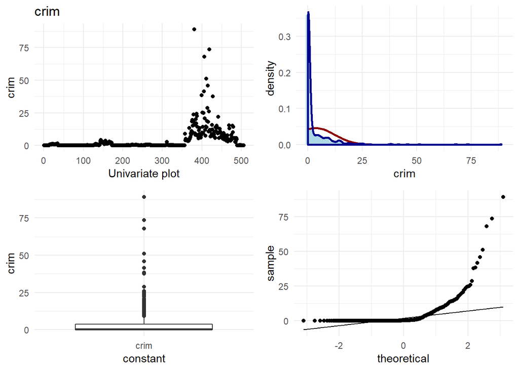

```
## [1] "Univariate plots for zn"
```

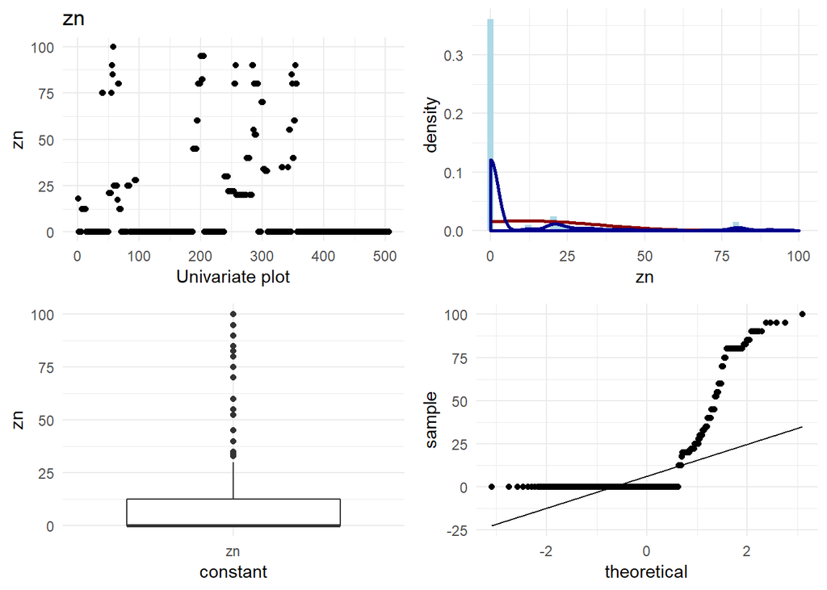

```
## [1] "Univariate plots for indus"
```

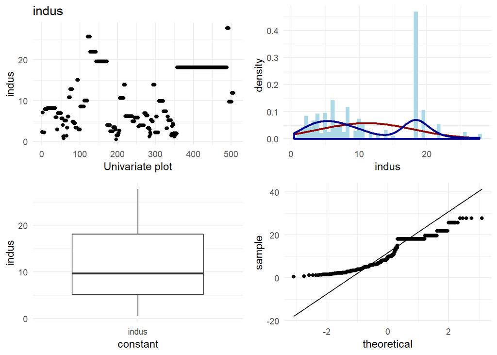

```
## [1] "Univariate plots for nox"
```

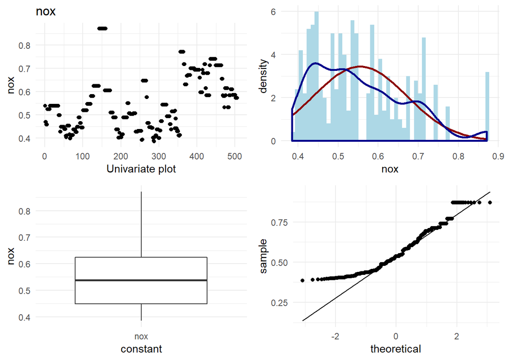

```
## [1] "Univariate plots for rm"
```

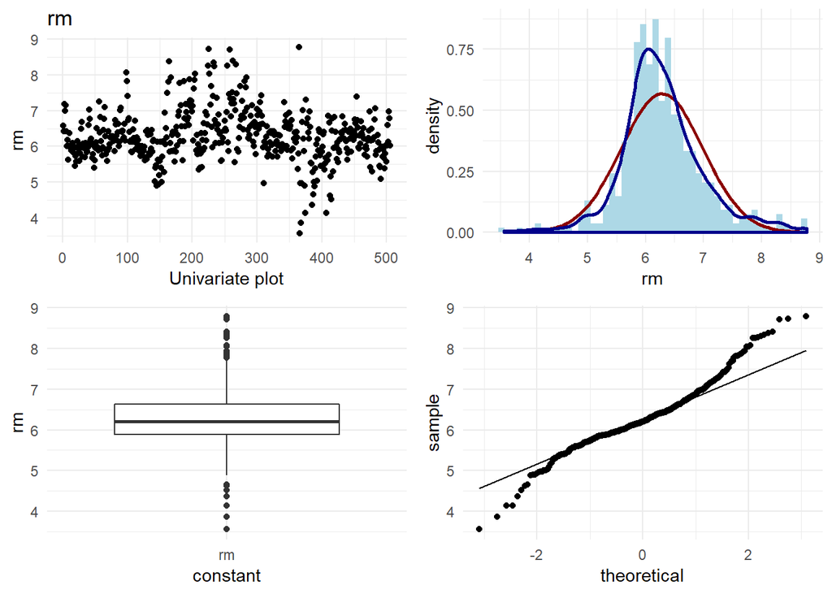

```
## [1] "Univariate plots for age"
```

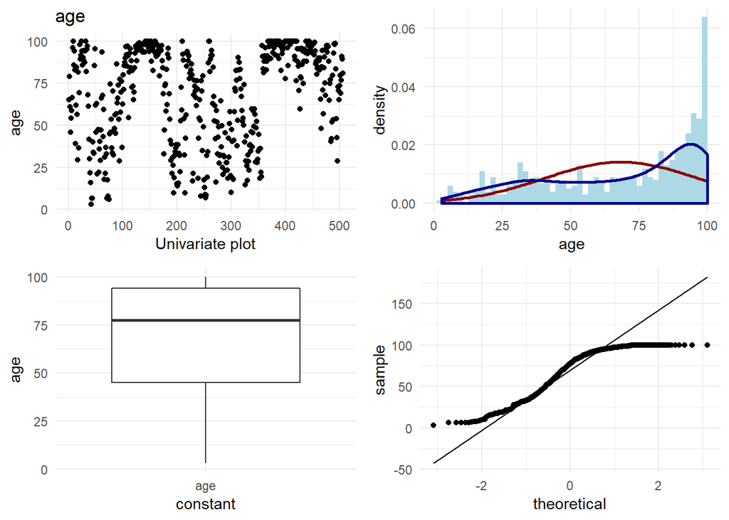

```
## [1] "Univariate plots for dis"
```

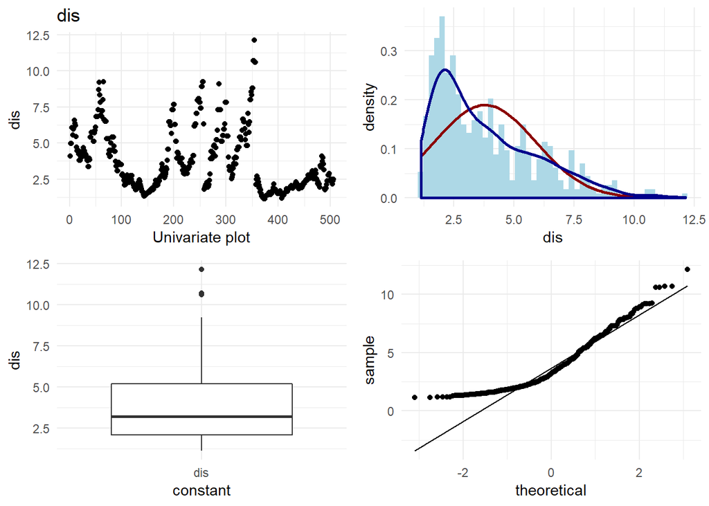

```
## [1] "Univariate plots for rad"
```

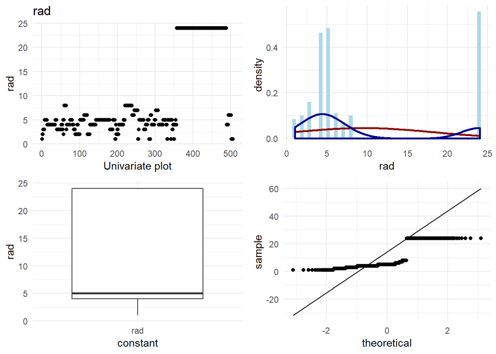

```
## [1] "Univariate plots for tax"
```

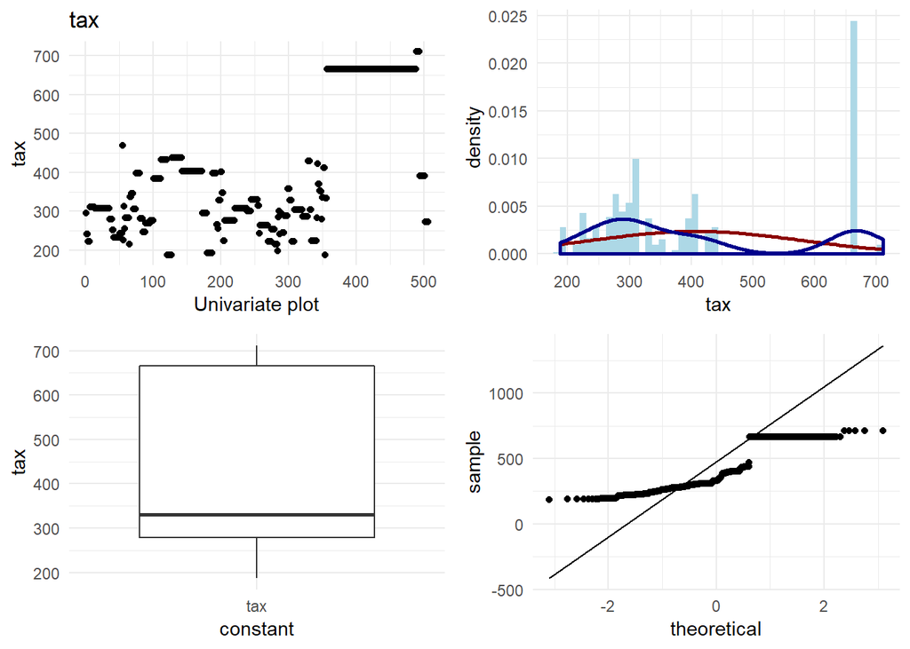

```
## [1] "Univariate plots for ptratio"
```

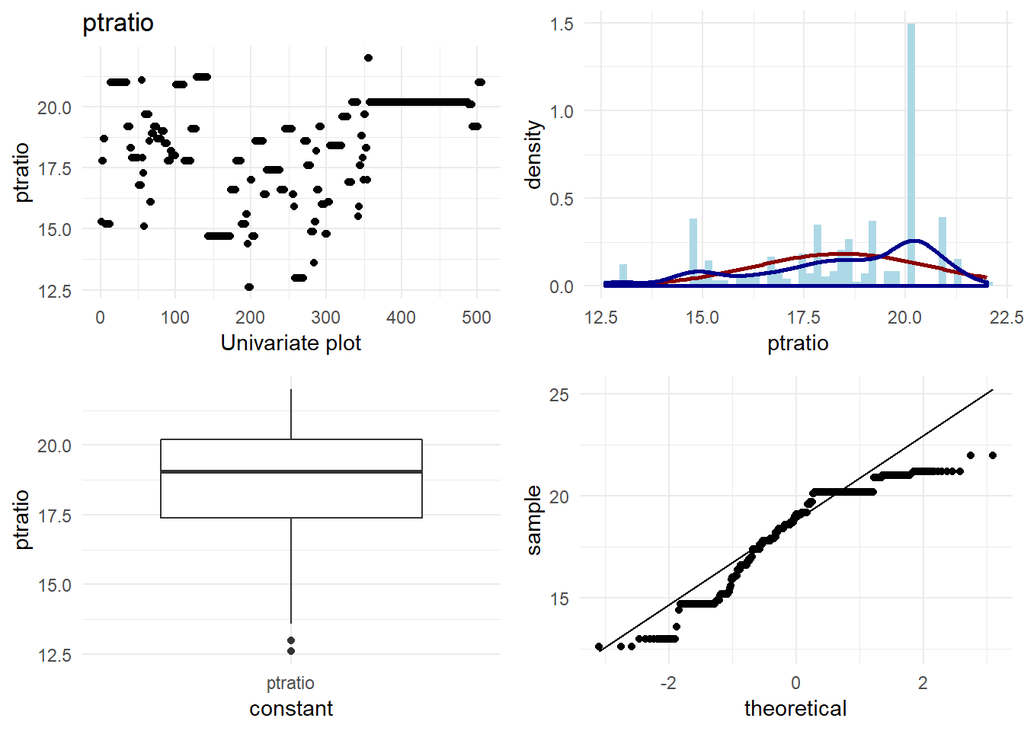

```
## [1] "Univariate plots for black"
```

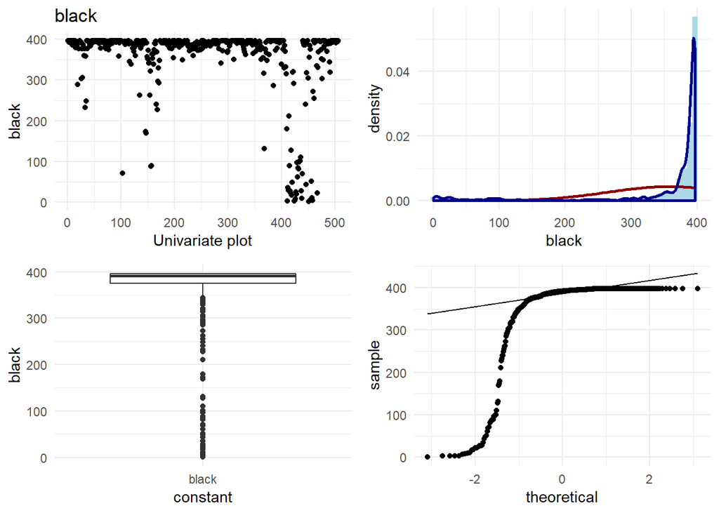

```
## [1] "Univariate plots for lstat"
```

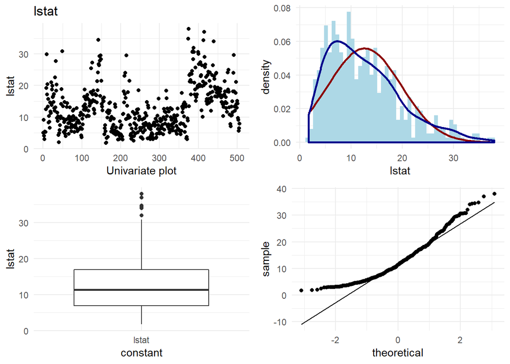

```
## [1] "Univariate plots for medv"
```

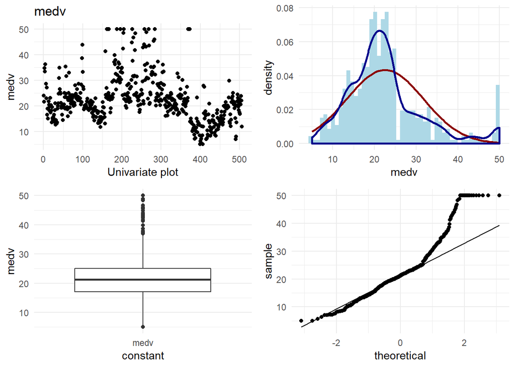

For categorical variables, I want to look at the frequencies.

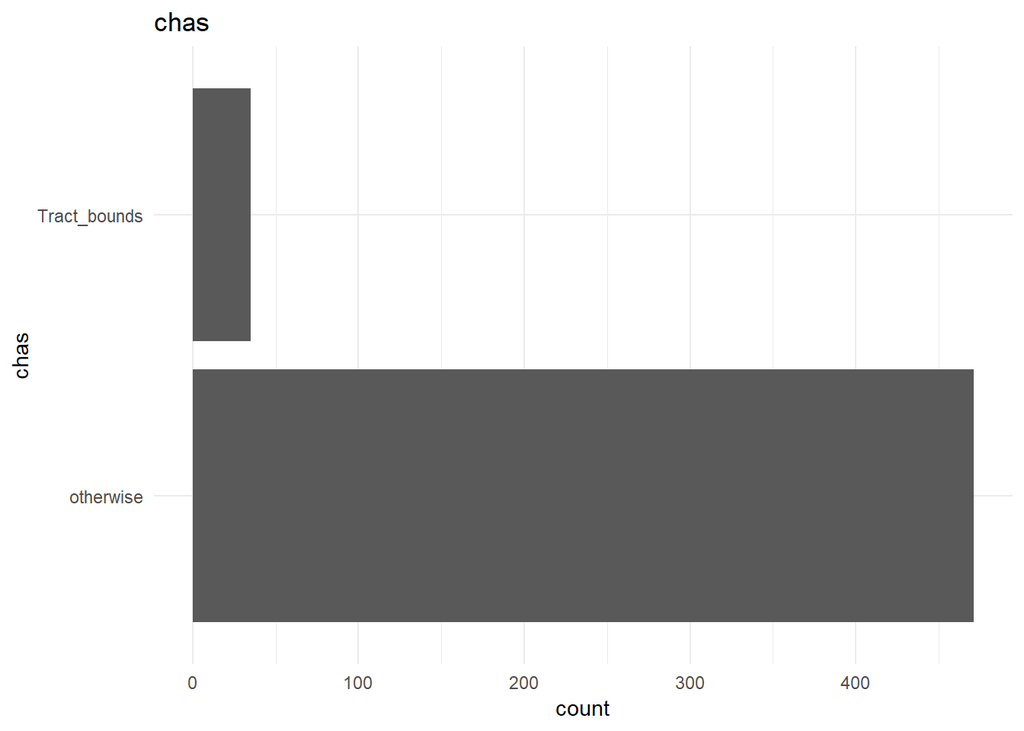

Therefore I am tempted to group the houses which have rad = 24 into one category, and create interaction variables of that column with *rad*, *indus*, *ptratio* and *tax*. The new variable is called *rad_cat*. Also, I would like to convert *rad* itself to categorical and see if it can explain better than continuous variable.  
Additionally, from researching on the internet, I found that the cost might have a different slope with the number of bedrooms for different class of people. So, I want to visualize that interaction variable also.

### Bi variate analysis

I want to understand the relationship of each continuous variable with the $y$ variable. I will achieve that by doing the following:  
1. A scatter plot to look at the relationship between the $x$ and the $y$ variables.  
2. Draw a linear regression line and a smoothed means line to understand the curve fit.  
3. Predict using Linear regression using the variable alone to observe the increase in R-squared.

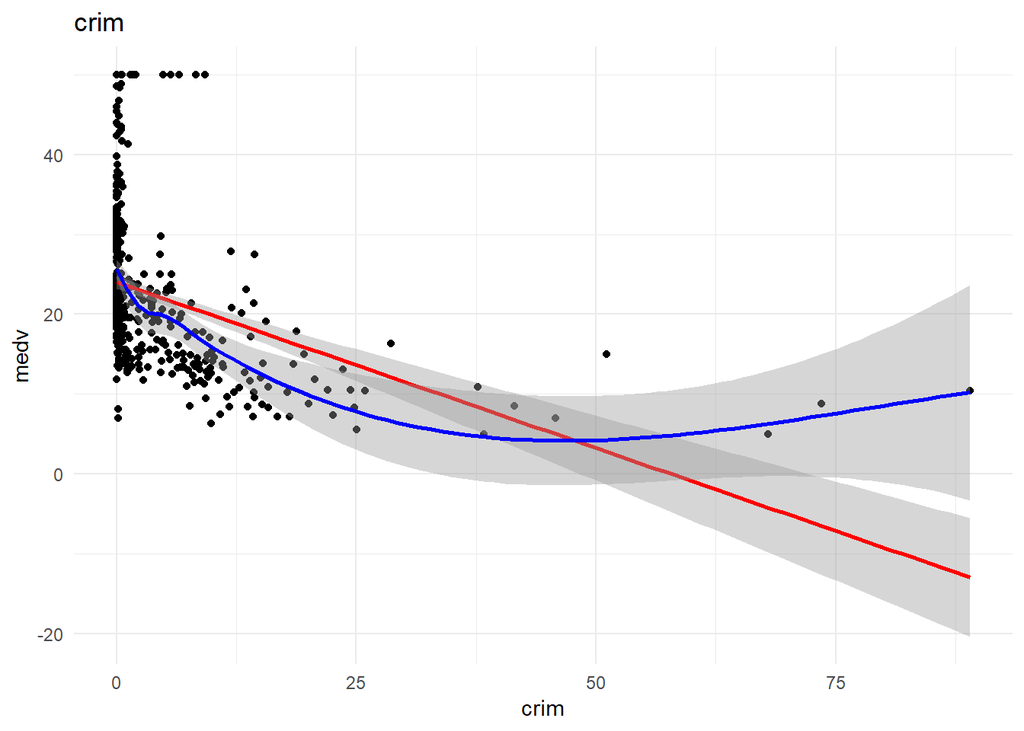

```
##
## Call:
## lm(formula = .outcome ~ ., data = dat)
##
## Residuals:
##     Min      1Q  Median      3Q     Max
## -15.816  -5.455  -1.970   2.633  29.615
##
## Coefficients:
##             Estimate Std. Error t value Pr(>|t|)
## (Intercept) 23.99736    0.45955  52.220  < 2e-16 ***
## crim        -0.39123    0.04855  -8.059 8.75e-15 ***
## ---
## Signif. codes:  0 '***' 0.001 '**' 0.01 '*' 0.05 '.' 0.1 ' ' 1
##
## Residual standard error: 8.595 on 405 degrees of freedom
## Multiple R-squared:  0.1382, Adjusted R-squared:  0.1361
## F-statistic: 64.94 on 1 and 405 DF,  p-value: 8.748e-15
##
## [1] "----------------------------------------------------------------------------------------------------"
```

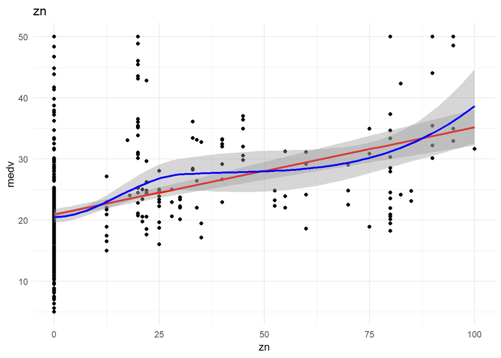

```
##
## Call:
## lm(formula = .outcome ~ ., data = dat)
##
## Residuals:
##      Min       1Q   Median       3Q      Max
## -15.9353  -5.6853  -0.9847   2.4653  29.0647
##
## Coefficients:
##             Estimate Std. Error t value Pr(>|t|)
## (Intercept) 20.93532    0.48739  42.954  < 2e-16 ***
## zn           0.14247    0.01818   7.835 4.15e-14 ***
## ---
## Signif. codes:  0 '***' 0.001 '**' 0.01 '*' 0.05 '.' 0.1 ' ' 1
##
## Residual standard error: 8.812 on 405 degrees of freedom
## Multiple R-squared:  0.1316, Adjusted R-squared:  0.1295
## F-statistic: 61.39 on 1 and 405 DF,  p-value: 4.155e-14
##
## [1] "----------------------------------------------------------------------------------------------------"
```

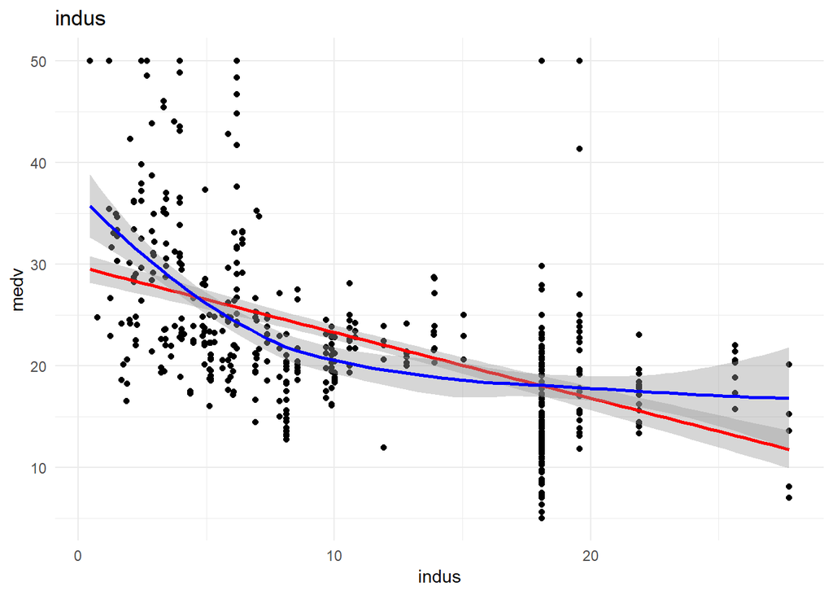

```
##
## Call:
## lm(formula = .outcome ~ ., data = dat)
##
## Residuals:
##     Min      1Q  Median      3Q     Max
## -12.922  -5.144  -1.631   2.972  33.069
##
## Coefficients:
##             Estimate Std. Error t value Pr(>|t|)
## (Intercept) 30.04045    0.77385   38.82   <2e-16 ***
## indus       -0.66951    0.05936  -11.28   <2e-16 ***
## ---
## Signif. codes:  0 '***' 0.001 '**' 0.01 '*' 0.05 '.' 0.1 ' ' 1
##
## Residual standard error: 8.249 on 405 degrees of freedom
## Multiple R-squared:  0.239,  Adjusted R-squared:  0.2372
## F-statistic: 127.2 on 1 and 405 DF,  p-value: < 2.2e-16
##
## [1] "----------------------------------------------------------------------------------------------------"
```

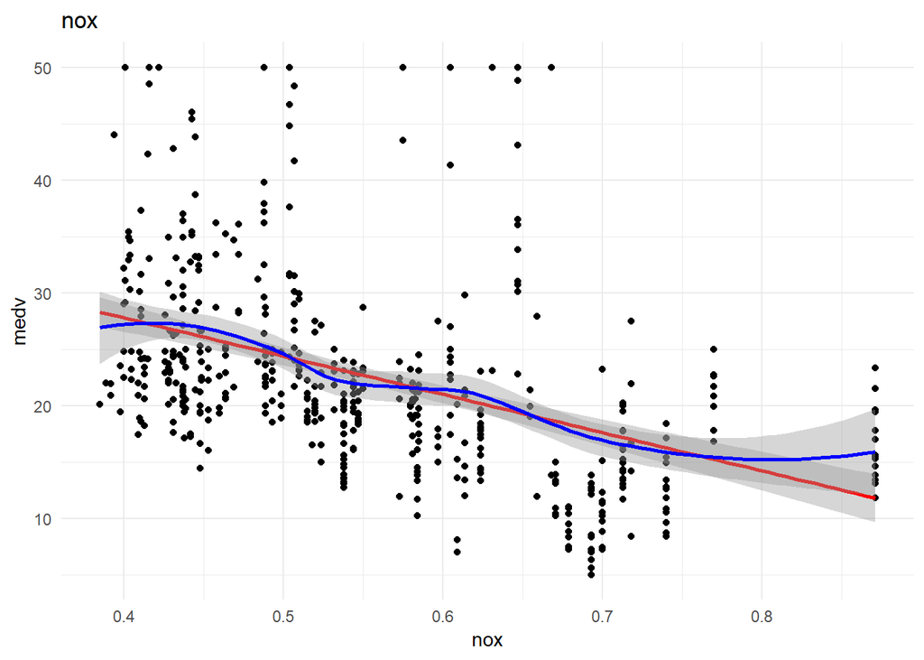

```
##
## Call:
## lm(formula = .outcome ~ ., data = dat)
##
## Residuals:
##     Min      1Q  Median      3Q     Max
## -13.688  -5.146  -2.299   2.794  30.643
##
## Coefficients:
##             Estimate Std. Error t value Pr(>|t|)
## (Intercept)   42.020      2.081  20.195   <2e-16 ***
## nox          -35.028      3.680  -9.518   <2e-16 ***
## ---
## Signif. codes:  0 '***' 0.001 '**' 0.01 '*' 0.05 '.' 0.1 ' ' 1
##
## Residual standard error: 8.548 on 405 degrees of freedom
## Multiple R-squared:  0.1828, Adjusted R-squared:  0.1808
## F-statistic:  90.6 on 1 and 405 DF,  p-value: < 2.2e-16
##
## [1] "----------------------------------------------------------------------------------------------------"
```

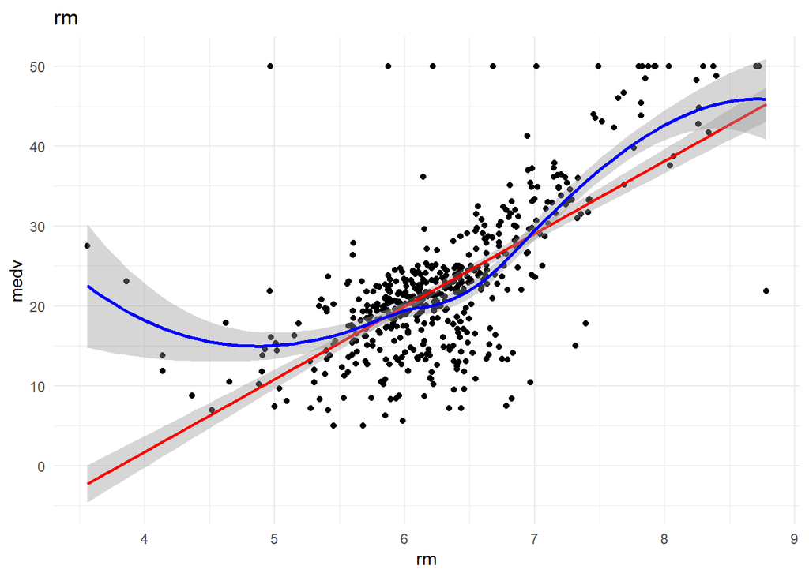

```
##
## Call:
## lm(formula = .outcome ~ ., data = dat)
##
## Residuals:
##     Min      1Q  Median      3Q     Max
## -19.886  -2.551   0.174   3.009  39.729
##
## Coefficients:
##             Estimate Std. Error t value Pr(>|t|)
## (Intercept) -36.6702     2.8680  -12.79   <2e-16 ***
## rm            9.4450     0.4538   20.81   <2e-16 ***
## ---
## Signif. codes:  0 '***' 0.001 '**' 0.01 '*' 0.05 '.' 0.1 ' ' 1
##
## Residual standard error: 6.574 on 405 degrees of freedom
## Multiple R-squared:  0.5168, Adjusted R-squared:  0.5156
## F-statistic: 433.1 on 1 and 405 DF,  p-value: < 2.2e-16
##
## [1] "----------------------------------------------------------------------------------------------------"
```

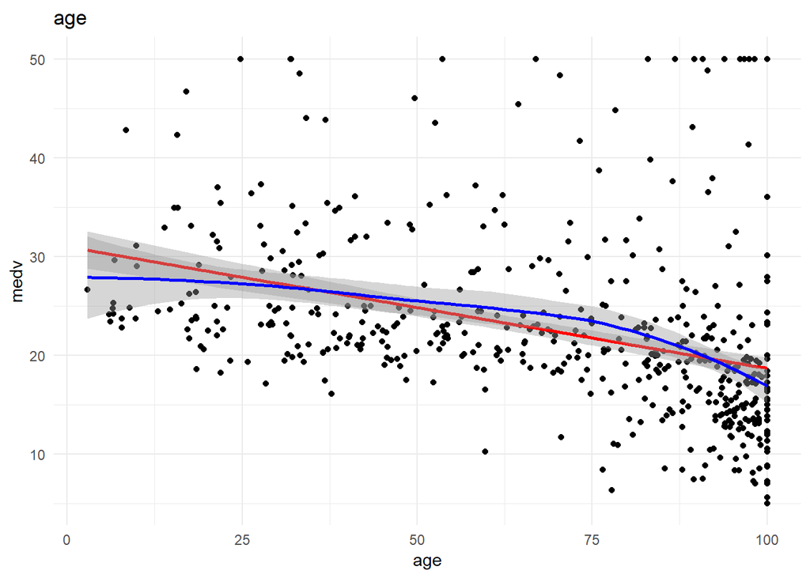

```
##
## Call:
## lm(formula = .outcome ~ ., data = dat)
##
## Residuals:
##     Min      1Q  Median      3Q     Max
## -15.138  -5.266  -2.033   2.333  31.332
##
## Coefficients:
##             Estimate Std. Error t value Pr(>|t|)
## (Intercept)  31.1468     1.1373  27.386  < 2e-16 ***
## age          -0.1248     0.0154  -8.104 6.33e-15 ***
## ---
## Signif. codes:  0 '***' 0.001 '**' 0.01 '*' 0.05 '.' 0.1 ' ' 1
##
## Residual standard error: 8.772 on 405 degrees of freedom
## Multiple R-squared:  0.1395, Adjusted R-squared:  0.1374
## F-statistic: 65.68 on 1 and 405 DF,  p-value: 6.333e-15
##
## [1] "----------------------------------------------------------------------------------------------------"
```

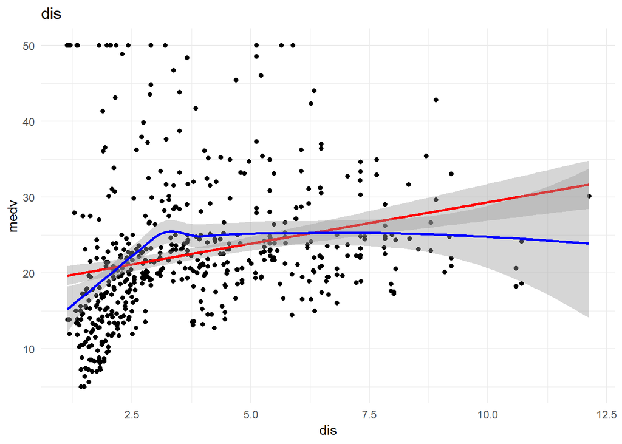

```
##
## Call:
## lm(formula = .outcome ~ ., data = dat)
##
## Residuals:
##     Min      1Q  Median      3Q     Max
## -15.010  -5.867  -1.968   2.297  30.275
##
## Coefficients:
##             Estimate Std. Error t value Pr(>|t|)
## (Intercept)  18.4243     0.9436  19.526  < 2e-16 ***
## dis           1.1127     0.2188   5.085 5.62e-07 ***
## ---
## Signif. codes:  0 '***' 0.001 '**' 0.01 '*' 0.05 '.' 0.1 ' ' 1
##
## Residual standard error: 9.168 on 405 degrees of freedom
## Multiple R-squared:  0.06002,    Adjusted R-squared:  0.0577
## F-statistic: 25.86 on 1 and 405 DF,  p-value: 5.619e-07
##
## [1] "----------------------------------------------------------------------------------------------------"
```

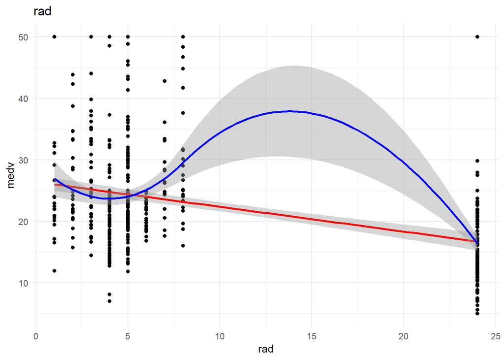

```
##
## Call:
## lm(formula = .outcome ~ ., data = dat)
##
## Residuals:
##     Min      1Q  Median      3Q     Max
## -18.022  -5.310  -2.298   3.375  33.475
##
## Coefficients:
##             Estimate Std. Error t value Pr(>|t|)
## (Intercept)  26.7220     0.6412  41.677   <2e-16 ***
## rad          -0.4249     0.0493  -8.619   <2e-16 ***
## ---
## Signif. codes:  0 '***' 0.001 '**' 0.01 '*' 0.05 '.' 0.1 ' ' 1
##
## Residual standard error: 8.693 on 405 degrees of freedom
## Multiple R-squared:  0.155,  Adjusted R-squared:  0.1529
## F-statistic: 74.28 on 1 and 405 DF,  p-value: < 2.2e-16
##
## [1] "----------------------------------------------------------------------------------------------------"
```

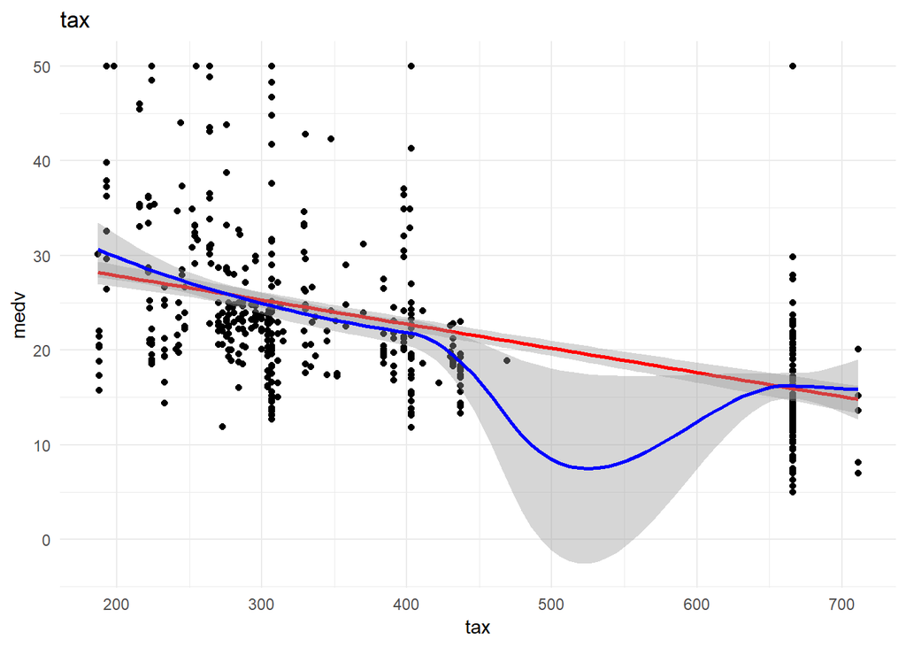

```
##
## Call:
## lm(formula = .outcome ~ ., data = dat)
##
## Residuals:
##     Min      1Q  Median      3Q     Max
## -13.039  -5.235  -2.191   3.166  34.209
##
## Coefficients:
##              Estimate Std. Error t value Pr(>|t|)
## (Intercept) 33.707058   1.080289   31.20   <2e-16 ***
## tax         -0.026900   0.002427  -11.09   <2e-16 ***
## ---
## Signif. codes:  0 '***' 0.001 '**' 0.01 '*' 0.05 '.' 0.1 ' ' 1
##
## Residual standard error: 8.283 on 405 degrees of freedom
## Multiple R-squared:  0.2328, Adjusted R-squared:  0.2309
## F-statistic: 122.9 on 1 and 405 DF,  p-value: < 2.2e-16
##
## [1] "----------------------------------------------------------------------------------------------------"
```

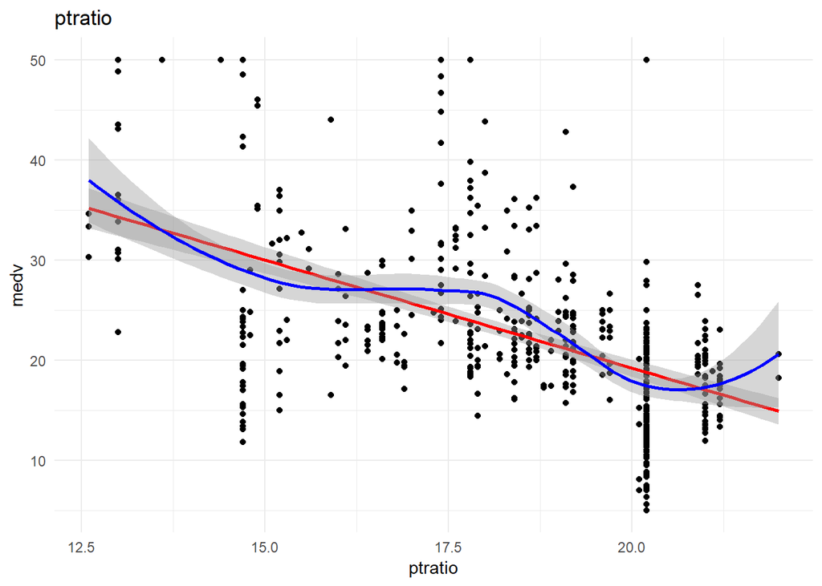

```
##
## Call:
## lm(formula = .outcome ~ ., data = dat)
##
## Residuals:
##      Min       1Q   Median       3Q      Max
## -19.4897  -4.9434  -0.7651   3.4363  31.2566
##
## Coefficients:
##             Estimate Std. Error t value Pr(>|t|)
## (Intercept)  64.8226     3.4209   18.95   <2e-16 ***
## ptratio      -2.2811     0.1837  -12.42   <2e-16 ***
## ---
## Signif. codes:  0 '***' 0.001 '**' 0.01 '*' 0.05 '.' 0.1 ' ' 1
##
## Residual standard error: 8.047 on 405 degrees of freedom
## Multiple R-squared:  0.2758, Adjusted R-squared:  0.274
## F-statistic: 154.2 on 1 and 405 DF,  p-value: < 2.2e-16
##
## [1] "----------------------------------------------------------------------------------------------------"
```

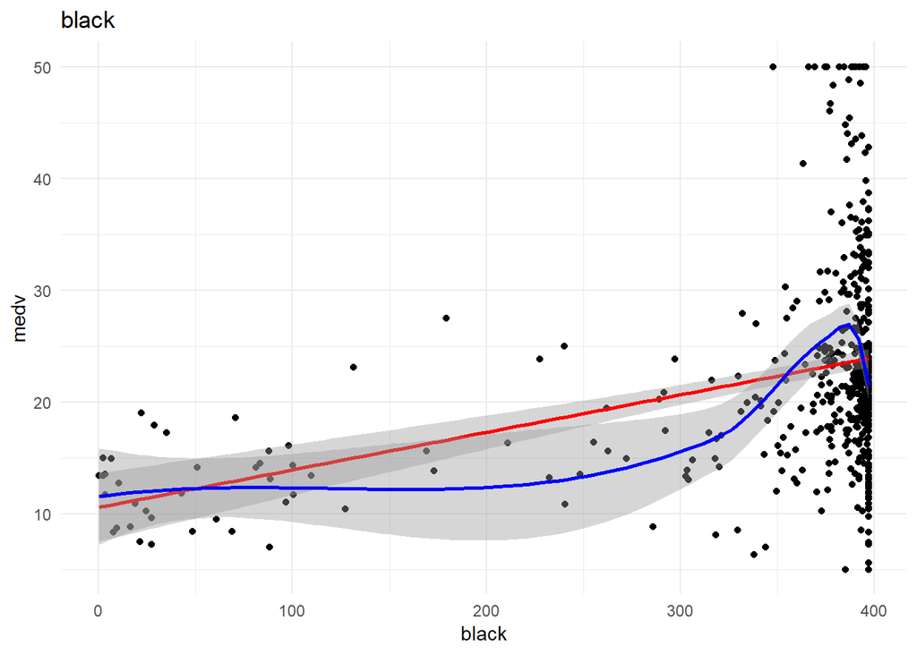

```
##
## Call:
## lm(formula = .outcome ~ ., data = dat)
##
## Residuals:
##     Min      1Q  Median      3Q     Max
## -18.573  -5.028  -1.864   2.874  27.066
##
## Coefficients:
##              Estimate Std. Error t value Pr(>|t|)
## (Intercept) 10.505391   1.785873   5.882 8.47e-09 ***
## black        0.033945   0.004844   7.008 1.02e-11 ***
## ---
## Signif. codes:  0 '***' 0.001 '**' 0.01 '*' 0.05 '.' 0.1 ' ' 1
##
## Residual standard error: 8.93 on 405 degrees of freedom
## Multiple R-squared:  0.1081, Adjusted R-squared:  0.1059
## F-statistic: 49.11 on 1 and 405 DF,  p-value: 1.017e-11
##
## [1] "----------------------------------------------------------------------------------------------------"
```

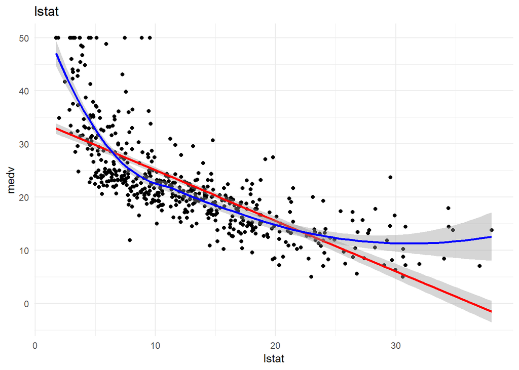

```
##
## Call:
## lm(formula = .outcome ~ ., data = dat)
##
## Residuals:
##     Min      1Q  Median      3Q     Max
## -10.023  -4.173  -1.390   2.172  24.327
##
## Coefficients:
##             Estimate Std. Error t value Pr(>|t|)
## (Intercept) 34.88480    0.63310   55.10   <2e-16 ***
## lstat       -0.96665    0.04336  -22.29   <2e-16 ***
## ---
## Signif. codes:  0 '***' 0.001 '**' 0.01 '*' 0.05 '.' 0.1 ' ' 1
##
## Residual standard error: 6.336 on 405 degrees of freedom
## Multiple R-squared:  0.551,  Adjusted R-squared:  0.5499
## F-statistic:   497 on 1 and 405 DF,  p-value: < 2.2e-16
##
## [1] "----------------------------------------------------------------------------------------------------"
```

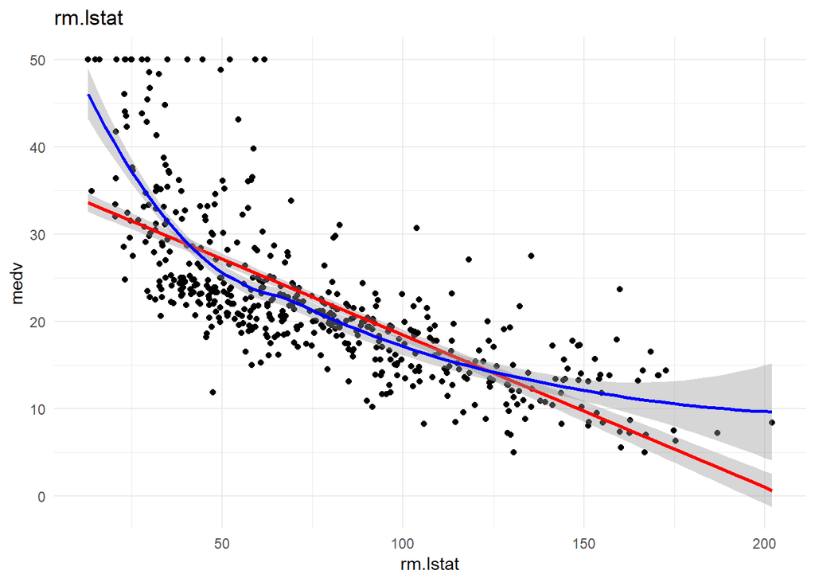

```
##
## Call:
## lm(formula = .outcome ~ ., data = dat)
##
## Residuals:
##     Min      1Q  Median      3Q     Max
## -10.849  -4.148  -1.339   2.469  24.772
##
## Coefficients:
##              Estimate Std. Error t value Pr(>|t|)
## (Intercept) 36.112064   0.696107   51.88   <2e-16 ***
## rm.lstat    -0.176325   0.008117  -21.72   <2e-16 ***
## ---
## Signif. codes:  0 '***' 0.001 '**' 0.01 '*' 0.05 '.' 0.1 ' ' 1
##
## Residual standard error: 6.36 on 405 degrees of freedom
## Multiple R-squared:  0.5382, Adjusted R-squared:  0.537
## F-statistic: 471.9 on 1 and 405 DF,  p-value: < 2.2e-16
##
## [1] "----------------------------------------------------------------------------------------------------"
```

Observations:  
1. *Crim* and *black* might have a non linear relationship with *medv*, I want further analysis on that front.  
2. As thought before *rad* might be better classified as a categorical variable.  
3. *lmstat* and *lm* might have a quadratic relationship with *medv*.

I want to understand the relationship of each categorical variable with the $y$ variable. I will achieve that by doing the following:  
1. A box plot showing the difference between variation of y between different classes of the variable.  
2. Density plot for each class in the variable to understand the distribution and spread of each class. (If the means were far away from each other and both the classes have small standard deviation, then the variables explainability is more)  
3. Predict using Linear regression using the variable alone to observe the increase in R-square

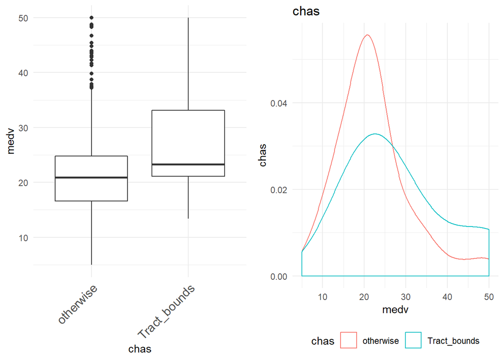

```
##
## Call:
## lm(formula = .outcome ~ ., data = dat)
##
## Residuals:
##     Min      1Q  Median      3Q     Max
## -17.189  -6.092  -1.389   2.812  27.811
##
## Coefficients:
##                  Estimate Std. Error t value Pr(>|t|)
## (Intercept)       22.1885     0.4766  46.553  < 2e-16 ***
## chasTract_bounds   6.9077     1.8858   3.663 0.000282 ***
## ---
## Signif. codes:  0 '***' 0.001 '**' 0.01 '*' 0.05 '.' 0.1 ' ' 1
##
## Residual standard error: 9.303 on 405 degrees of freedom
## Multiple R-squared:  0.03207,    Adjusted R-squared:  0.02968
## F-statistic: 13.42 on 1 and 405 DF,  p-value: 0.0002823
##
## [1] "----------------------------------------------------------------------------------------------------"
```

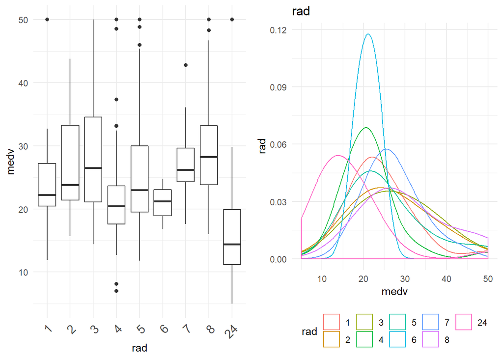

```
##
## Call:
## lm(formula = .outcome ~ ., data = dat)
##
## Residuals:
##     Min      1Q  Median      3Q     Max
## -14.853  -5.471  -1.853   3.545  33.741
##
## Coefficients:
##             Estimate Std. Error t value Pr(>|t|)
## (Intercept)  25.3692     2.3093  10.986  < 2e-16 ***
## rad2          1.8117     2.9384   0.617 0.537872
## rad3          2.7756     2.7791   0.999 0.318530
## rad4         -3.9421     2.4671  -1.598 0.110865
## rad5          0.9137     2.4638   0.371 0.710934
## rad6         -4.4587     2.9969  -1.488 0.137609
## rad7          1.3308     3.2070   0.415 0.678396
## rad8          5.4837     3.0677   1.788 0.074610 .
## rad24        -9.1100     2.4443  -3.727 0.000222 ***
## ---
## Signif. codes:  0 '***' 0.001 '**' 0.01 '*' 0.05 '.' 0.1 ' ' 1
##
## Residual standard error: 8.326 on 398 degrees of freedom
## Multiple R-squared:  0.2381, Adjusted R-squared:  0.2228
## F-statistic: 15.55 on 8 and 398 DF,  p-value: < 2.2e-16
##
## [1] "----------------------------------------------------------------------------------------------------"
```

Observations:  
1. *rad* as a categorical feature explains more as a categorical variable with R-Square of 0.2381 when compared to continuous variable with a R-square of 0.155. From the box plot I can observe that the class ‘rad24’ is different from all the other classes. That is what is being shown in the regression equation. If ‘rad1’ was my base class, then all other classes are similar except for ‘rad24’ which is significantly different from base class. This validates my initial creation of interaction variables with *rad_cat* too.  
2. There seems to be significant difference between the houses that are Charles River track-bound or otherwise.

### Correlation

The correlation between different variables is as follows

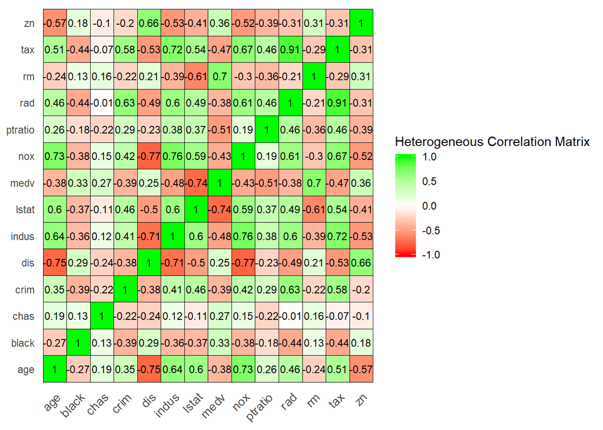

Observations:  
1. There is a lot of correlation between a large number of location based features like *dis* and *nox*, *dist* and *indus*, *dist* and *age*, *rm* and *lstat*, *lstat* and *indus* etc. The correlations between different (continuous) variables can be visualized below.

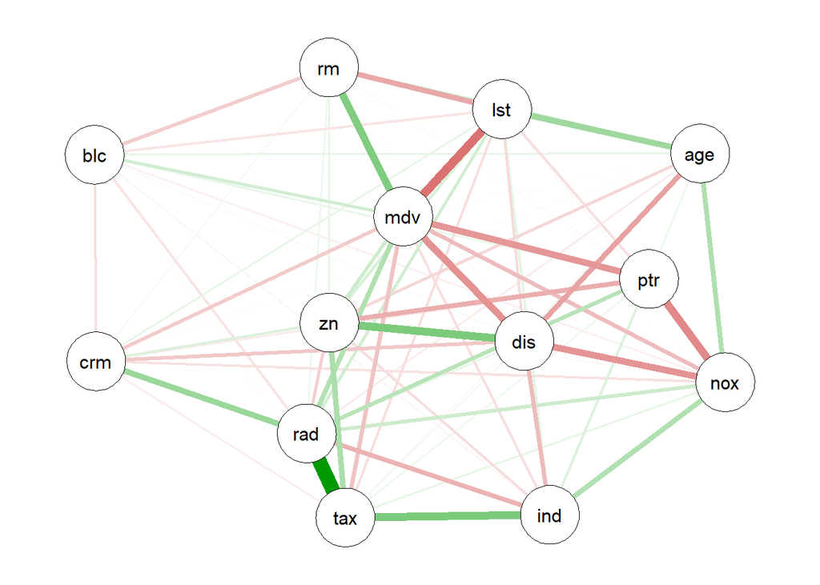

## Initial Model Training

For my initial model, I am training using step wise linear regression. In every step, I want to observe the following:  
1. What variables are added or removed from the model. The current model pics the column which gives the greatest decrease in AIC. The model stops when the decrease in AIC w.r.t. null(no change) is lower than the threshold.  
2. Substantial increase/decrease in $\beta$ or change in its sign (which may be due to colliniarity between the dependent variables)

```
## Start:  AIC=1297.43
## .outcome ~ crim + zn + indus + chasTract_bounds + nox + rm +
##     age + dis + tax + ptratio + black + lstat + rad_catloc24
##
##                    Df Sum of Sq     RSS    AIC
## - age               1      0.72  9208.4 1295.5
## - indus             1      3.76  9211.5 1295.6
## <none>                           9207.7 1297.4
## - chasTract_bounds  1     97.13  9304.8 1299.7
## - tax               1    118.38  9326.1 1300.6
## - zn                1    168.98  9376.7 1302.8
## - black             1    191.17  9398.9 1303.8
## - crim              1    307.05  9514.7 1308.8
## - rad_catloc24      1    314.92  9522.6 1309.1
## - nox               1    352.63  9560.3 1310.7
## - ptratio           1    957.94 10165.6 1335.7
## - dis               1    994.35 10202.0 1337.2
## - rm                1   1892.99 11100.7 1371.5
## - lstat             1   2127.87 11335.6 1380.0
##
## Step:  AIC=1295.46
## .outcome ~ crim + zn + indus + chasTract_bounds + nox + rm +
##     dis + tax + ptratio + black + lstat + rad_catloc24
##
##                    Df Sum of Sq     RSS    AIC
## - indus             1      3.65  9212.1 1293.6
## <none>                           9208.4 1295.5
## + age               1      0.72  9207.7 1297.4
## - chasTract_bounds  1     97.93  9306.3 1297.8
## - tax               1    118.46  9326.9 1298.7
## - zn                1    168.59  9377.0 1300.8
## - black             1    193.24  9401.6 1301.9
## - crim              1    306.48  9514.9 1306.8
## - rad_catloc24      1    314.22  9522.6 1307.1
## - nox               1    369.87  9578.3 1309.5
## - ptratio           1    960.19 10168.6 1333.8
## - dis               1   1087.43 10295.8 1338.9
## - rm                1   1970.22 11178.6 1372.4
## - lstat             1   2321.66 11530.1 1385.0
##
## Step:  AIC=1293.62
## .outcome ~ crim + zn + chasTract_bounds + nox + rm + dis + tax +
##     ptratio + black + lstat + rad_catloc24
##
##                    Df Sum of Sq     RSS    AIC
## <none>                           9212.1 1293.6
## + indus             1      3.65  9208.4 1295.5
## + age               1      0.61  9211.5 1295.6
## - chasTract_bounds  1     95.50  9307.6 1295.8
## - tax               1    152.24  9364.3 1298.3
## - zn                1    174.02  9386.1 1299.2
## - black             1    196.27  9408.3 1300.2
## - crim              1    303.79  9515.9 1304.8
## - rad_catloc24      1    335.42  9547.5 1306.2
## - nox               1    417.91  9630.0 1309.7
## - ptratio           1    982.91 10195.0 1332.9
## - dis               1   1125.61 10337.7 1338.5
## - rm                1   2045.55 11257.6 1373.2
## - lstat             1   2330.94 11543.0 1383.4
```

```
##
## Call:
## lm(formula = .outcome ~ crim + zn + chasTract_bounds + nox +
##     rm + dis + tax + ptratio + black + lstat + rad_catloc24,
##     data = dat)
##
## Residuals:
##      Min       1Q   Median       3Q      Max
## -16.1877  -2.7794  -0.5639   1.8186  26.2200
##
## Coefficients:
##                    Estimate Std. Error t value Pr(>|t|)
## (Intercept)       35.638467   5.799094   6.146 1.95e-09 ***
## crim              -0.125142   0.034673  -3.609 0.000347 ***
## zn                 0.042184   0.015443   2.732 0.006585 **
## chasTract_bounds   2.030470   1.003385   2.024 0.043682 *
## nox              -17.255174   4.076237  -4.233 2.87e-05 ***
## rm                 4.120294   0.439949   9.365  < 2e-16 ***
## dis               -1.476732   0.212563  -6.947 1.54e-11 ***
## tax               -0.010071   0.003942  -2.555 0.010994 *
## ptratio           -0.961287   0.148073  -6.492 2.55e-10 ***
## black              0.008800   0.003033   2.901 0.003928 **
## lstat             -0.526372   0.052651  -9.997  < 2e-16 ***
## rad_catloc24       5.669076   1.494858   3.792 0.000173 ***
## ---
## Signif. codes:  0 '***' 0.001 '**' 0.01 '*' 0.05 '.' 0.1 ' ' 1
##
## Residual standard error: 4.829 on 395 degrees of freedom
## Multiple R-squared:  0.7474, Adjusted R-squared:  0.7404
## F-statistic: 106.2 on 11 and 395 DF,  p-value: < 2.2e-16
```

Summary:  
1. Initially all the factors were considered in the model.  
2. By removing *age* from the initial model, the AIC is 1295.5 vs 1297.43 in the initial model. Therefore *age* was removed.  
3. By removing *industry* from the initial model, the AIC is 1293.6 vs the AIC of 1297.43. Therefore *industry* was removed.  
4. Adding or removing any other variable does not decrease AIC significantly. The remaining factors are the best factors of the final model.

Observations:  
1. For every unit increase in crime, the price decreases by 0.12 units.  
2. For every large residential properties, the price increases by 0.0421 units.  
3. For every unit increase in NOX(pollution) levels, the price decreases by -17.25 units.  
4. The presence of Charles river in track bounds increases the price of the property by 2.03 units.  
5. One extra room increases the price by 4.12  
6. Increase in average distance from work centers by 1 unit decreases the price by 1.47 units.  
7. Increase in tax by one unit decreases the price by -0.01 units.  
8. Surprisingly, increasing the parent teacher ratio by one unit, decreases the price by 0.96 units.  
9. Racial discrimination is still an important factor.  
10.One unit increase of lower status of the population decreases the price by 0.52 units.  
11.The presence of ‘rad=24’ increases the price by 5.6 units.

## Model diagnostics

### The R-Squared and RMSE of the model on test data are:

```
##      RMSE  Rsquared       MAE
## 4.5506048 0.6797879 3.2017260
```

R-Square remains similar on the test set. Therefore we are not over-fitting.

### Testing statistical significance of individual dependent variables

The Null hypothesis and alternate hypothesis for each of the dependent variables $i$ is:
$$H_0 : \beta_i= 0$$
$$H_1 : \beta_i \neq 0$$
The statistical significance can be validated using a t-test.

### Validating the complete model

The null and alternate hypothesis for the model $y = \beta_0 + \beta_1x_1 + \beta_2x_2+...+\beta_kx_k + \epsilon$ is:
$$H_0 : \beta_1 = \beta_2 = ... = \beta_k = 0$$
$$H_1 : Not \, all\, \beta_i \,are\, 0$$
The statistical significance can be validated using F test.

```
##
## Call:
## lm(formula = .outcome ~ crim + zn + chasTract_bounds + nox +
##     rm + dis + tax + ptratio + black + lstat + rad_catloc24,
##     data = dat)
##
## Residuals:
##      Min       1Q   Median       3Q      Max
## -16.1877  -2.7794  -0.5639   1.8186  26.2200
##
## Coefficients:
##                    Estimate Std. Error t value Pr(>|t|)
## (Intercept)       35.638467   5.799094   6.146 1.95e-09 ***
## crim              -0.125142   0.034673  -3.609 0.000347 ***
## zn                 0.042184   0.015443   2.732 0.006585 **
## chasTract_bounds   2.030470   1.003385   2.024 0.043682 *
## nox              -17.255174   4.076237  -4.233 2.87e-05 ***
## rm                 4.120294   0.439949   9.365  < 2e-16 ***
## dis               -1.476732   0.212563  -6.947 1.54e-11 ***
## tax               -0.010071   0.003942  -2.555 0.010994 *
## ptratio           -0.961287   0.148073  -6.492 2.55e-10 ***
## black              0.008800   0.003033   2.901 0.003928 **
## lstat             -0.526372   0.052651  -9.997  < 2e-16 ***
## rad_catloc24       5.669076   1.494858   3.792 0.000173 ***
## ---
## Signif. codes:  0 '***' 0.001 '**' 0.01 '*' 0.05 '.' 0.1 ' ' 1
##
## Residual standard error: 4.829 on 395 degrees of freedom
## Multiple R-squared:  0.7474, Adjusted R-squared:  0.7404
## F-statistic: 106.2 on 11 and 395 DF,  p-value: < 2.2e-16
```

From the above summary, I can observe that the *Pr(>|t|)* or p-value is less than the cutoff value of $\alpha = 0.05$ for all variables. Also the F-Statistic is 106.2 with a p value <2.2e-16. Thus I reject both the above null hypothesis. The model is statistically significant.